# Task-2

## Task-2:- From the given ‘Iris’ dataset, predict the optimum number of clusters and represent it visually.

### We will use the following packages to build the model:

- Pandas Dataframe to read the csv file and get the data in a tabular form.
- From matplotlib we import pyplot to plot and get insights about the data.
- Load the dataset from sklearn package
- We will use the elbow method to find the optimum number of clusters
- Using K-means clustering, we fit the model to partition the given data into the clusters
- Finally plot a graph to observe the partitioned data with their respective centroids.

```python
import pandas as pd
import numpy as np
from sklearn import datasets
import matplotlib.pyplot as plt
```

```python
data=datasets.load_iris()
```

```python
data=pd.DataFrame(data.data, columns = data.feature_names)
```

```python
data.head(5)
```

|  | sepal length (cm) | sepal width (cm) | petal length (cm) | petal width (cm) |
| --- | --- | --- | --- | --- |
| 0 | 5.1 | 3.5 | 1.4 | 0.2 |
| 1 | 4.9 | 3.0 | 1.4 | 0.2 |
| 2 | 4.7 | 3.2 | 1.3 | 0.2 |
| 3 | 4.6 | 3.1 | 1.5 | 0.2 |
| 4 | 5.0 | 3.6 | 1.4 | 0.2 |

```python
data.shape
```

```
(150, 4)
```

```python
x=data.drop(["petal length (cm)","petal width (cm)"],axis=1)
y=data.drop(["sepal length (cm)","sepal width (cm)"],axis=1)
```

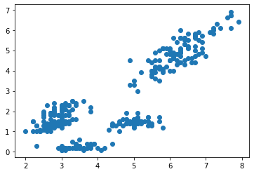

```python
plt.scatter(x,y)
plt.show()
```

### K-Means Clustering

- Plot the graph of k(no.of clusters) vs SSE
- SSE is sum of squared distances of data points to their closest cluster center
- Choose appropriate k where error is minimum or significantlly not reducing further

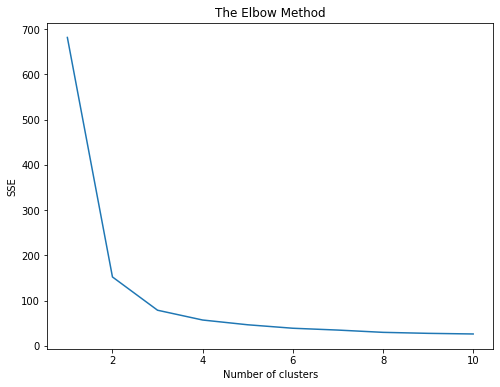

```python
import matplotlib.pyplot as plt
from sklearn.cluster import KMeans

x=data.iloc[:,[0,1,2,3]].values

# using the elbow method to find the optimal no. of clusters

ls=[]
for i in range(1,11):
    km=KMeans(n_clusters=i)
    km.fit(x)
    ls.append(km.inertia_) #sum of squared distances of samples to their closest cluster center

plt.figure(figsize=(8,6))
plt.plot(range(1,11),ls)
plt.title("The Elbow Method")
plt.xlabel("Number of clusters")
plt.ylabel("SSE")
plt.show()
```

### The points where the SSE reduces or the point where you can see the elbow shaped portion,those will be the ideal values of no. of clusters.So in above case 2 and 3 are the no. of clusters.Among them we choose the ideal value as 3 beacsue, after 3 there is not much of drastic change in SSE.

```python
from sklearn.cluster import KMeans
km=KMeans(n_clusters=3)
km.fit(x)
print("The centers of clusters are:\n",km.cluster_centers_)
print("Cluster Labels",km.labels_)
```

```
The centers of clusters are:
 [[5.006      3.428      1.462      0.246     ]
 [5.9016129  2.7483871  4.39354839 1.43387097]
 [6.85       3.07368421 5.74210526 2.07105263]]
Cluster Labels [0 0 0 0 0 0 0 0 0 0 0 0 0 0 0 0 0 0 0 0 0 0 0 0 0 0 0 0 0 0 0 0 0 0 0 0 0
 0 0 0 0 0 0 0 0 0 0 0 0 0 1 1 2 1 1 1 1 1 1 1 1 1 1 1 1 1 1 1 1 1 1 1 1 1
 1 1 1 2 1 1 1 1 1 1 1 1 1 1 1 1 1 1 1 1 1 1 1 1 1 1 2 1 2 2 2 2 1 2 2 2 2
 2 2 1 1 2 2 2 2 1 2 1 2 1 2 2 1 1 2 2 2 2 2 1 2 2 2 2 1 2 2 2 1 2 2 2 1 2
 2 1]
```

```python
ykmeans=km.fit_predict(x)
```

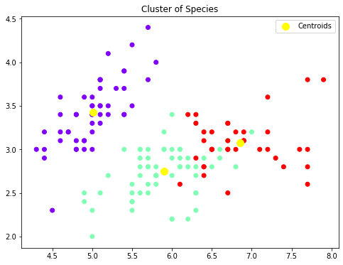

```python
plt.figure(figsize=[8,6])
plt.scatter(x[:,0],x[:,1],c=km.labels_,cmap='rainbow')
plt.scatter(km.cluster_centers_[:,0],km.cluster_centers_[:,1],s=100,c="yellow",label="Centroids")
plt.title("Cluster of Species")
plt.legend()
plt.show()
```

### The number of clusters can therefore be classified into three Species of Iris Flower i.e setosa, versicolor, or virginica from measurements of sepals and petals' length and width.

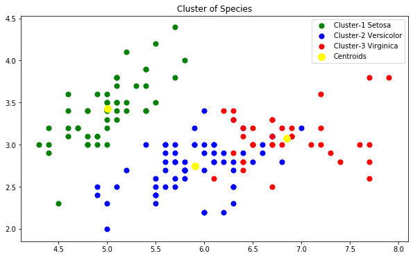

```python
#alternative method visualising clusters i.e. assigning color of our choice

plt.figure(figsize=(10,6))
plt.scatter(x[ykmeans==0,0],x[ykmeans==0,1],s=50,c="green",label="Cluster-1 Setosa")

plt.scatter(x[ykmeans==1,0],x[ykmeans==1,1],s=50,c="blue",label="Cluster-2 Versicolor")

plt.scatter(x[ykmeans==2,0],x[ykmeans==2,1],s=50,c="red",label="Cluster-3 Virginica")


plt.scatter(km.cluster_centers_[:,0],km.cluster_centers_[:,1],s=100,c="yellow",label="Centroids")
plt.title("Cluster of Species")
plt.legend()
plt.show()
```